# Response to Reviewer 2: sensitivity to archaeological search radius

## Reviewer comment

The reviewer questioned whether archaeological activity summarized within a fixed distance of each pollen record adequately represents the spatial scale of the vegetation record, and asked whether our conclusions are sensitive to the use of a 250 km rather than a 500 km search radius.

## Response

We agree that this spatial choice requires an explicit sensitivity test. Pollen records describe vegetation change from local to regional source areas, whereas radiocarbon-dated archaeological sites are discrete and unevenly distributed across the landscape. A smaller archaeological search radius gives greater weight to evidence closer to the pollen site, but in sparsely studied regions it may contain too few radiocarbon dates to describe human activity reliably. A larger radius increases the amount of archaeological evidence, but represents a broader human landscape around the pollen site. No single fixed radius can reproduce the pollen source area of every lake or bog; our aim was therefore to test whether this unavoidable spatial choice changes the ecological interpretation.

We recalculated the archaeological SPD for every pollen record using two strict search radii, 250 km and 500 km, while keeping the radiocarbon data, calibration, time range, smoothing, climate data, and statistical analyses unchanged. We then compared the two radii for the same pollen records. This design isolates the effect of changing the archaeological neighbourhood, rather than confounding it with changes in the vegetation or climate data.

The primary analysis uses 250 km wherever sufficient archaeological evidence is available and expands to 500 km only where the 250 km series is unavailable. This choice retains the most spatially local estimate that the data support. Of 1270 pollen records, 1044 have a usable 250 km series. The 500 km fallback recovers a further 137 records, giving usable archaeological information for 1181 records in total. Thus, the fallback is a pragmatic compromise between spatial proximity and geographical coverage, rather than an assumption that 250 km or 500 km is the true pollen source area.

Figure 1 asks whether widening the archaeological neighbourhood changes the relative allocation of positive hierarchical contributions between human activity and climate for individual pollen records. Negative hierarchical fractions are set to zero and the remaining positive human, climate, and temporal components are renormalised to sum to one. The plotted balance is the human share minus the climate share. Values below zero therefore indicate greater relative climatic importance and values above zero greater relative human importance. This composition is distinct from the absolute amount of variation explained. In panel A, each line connects the result for the same pollen record at 250 km and 500 km; short lines therefore indicate little sensitivity to radius. Panel B summarizes the shift within continents and climate zones. The median change across 999 comparable pollen records was 0.025 (interquartile range -0.067 to 0.227). The continent and climate-zone median shifts generally remain near zero, although some intervals are broad because responses differ among records. There is no consistent movement towards either stronger climatic or stronger human influence when the radius is enlarged.

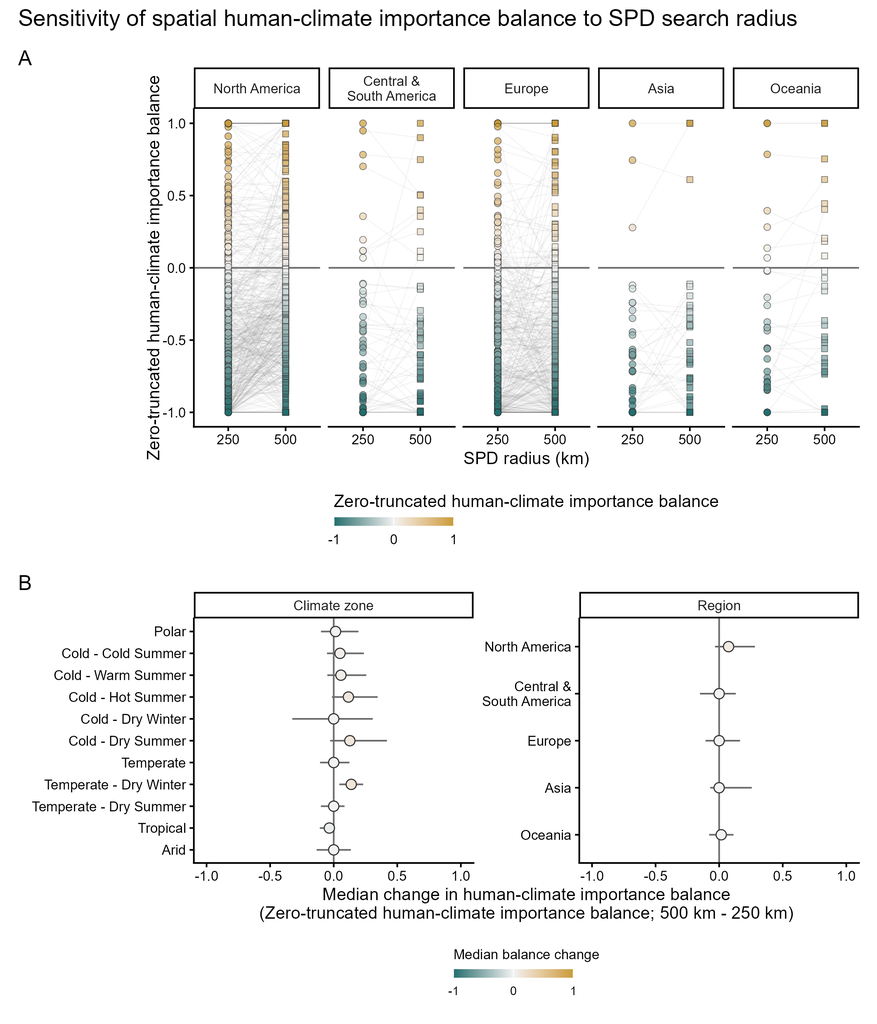

Figure 1: Sensitivity of the zero-truncated human–climate importance balance to archaeological search radius. Negative hierarchical fractions were set to zero and the positive human, climate, and temporal components were renormalised to sum to one. (A) Each line connects the same pollen record analysed with archaeological evidence from within 250 km and 500 km. Negative values (teal) indicate a greater climate share, positive values (gold) indicate a greater human share, and white marks equal shares. (B) Median changes after increasing the radius from 250 km to 500 km are shown for continents and climate zones; points close to zero indicate little overall change.

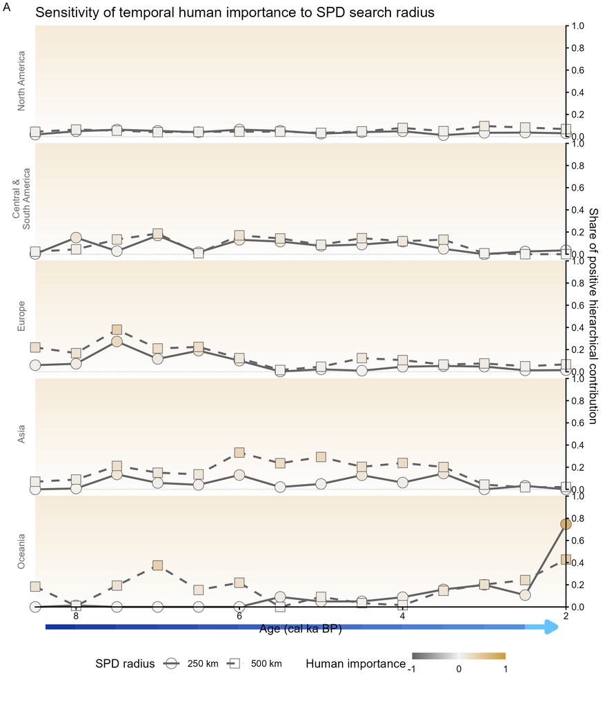

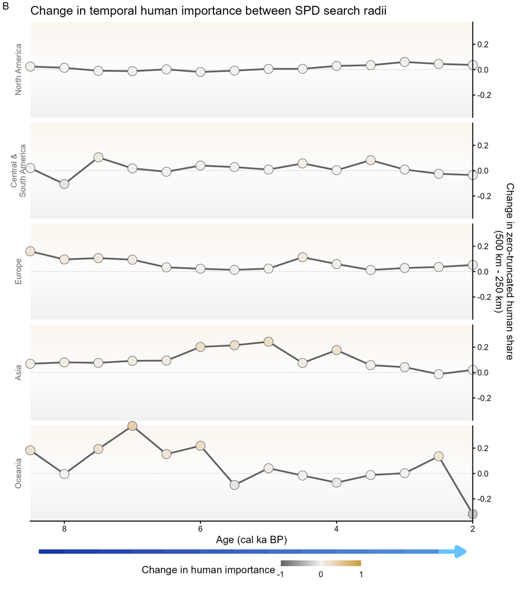

Figure 3: Change in the zero-truncated human share after increasing the archaeological search radius from 250 km to 500 km. Positive values indicate a larger human share at 500 km, negative values indicate a smaller share, and zero indicates no change in the relative composition. Continents are displayed as separate rows and the blue arrow indicates the direction from older to younger ages. Values clustered around zero show that the temporal pattern is only weakly sensitive to search radius.

Together, the three figures show that changing from a 250 km to a 500 km archaeological neighbourhood has only a small effect on the relative composition and history of inferred human importance. The sensitivity analysis therefore supports our methodology: using the 250 km SPD where possible preserves the closest available link between archaeological activity and the pollen record, while the 500 km fallback improves coverage in archaeologically sparse areas without changing the broad ecological patterns. Most importantly, the main large-scale result remains unchanged: climate is a stronger predictor than human activity of broad-scale vegetation patterns.

## Methods insertion

To test whether the spatial scale used to summarize archaeological evidence affected our conclusions, we recalculated the radiocarbon SPD for every pollen record using strict 250 km and 500 km search radii. Both calculations used the same radiocarbon dataset, calibration choices, 0–12 ka time range, 100-year smoothing, and minimum requirement of more than 50 radiocarbon dates. All vegetation, climate, and analytical settings were held constant, so the only difference between the two analyses was the archaeological search radius. We compared results for the same pollen records and for the same continental time steps at both radii. The primary analysis used the 250 km SPD whenever sufficient dates were available and the 500 km SPD otherwise, thereby favouring the most local archaeological context while retaining records from data-sparse regions.

## Discussion insertion

The archaeological radius represents a trade-off between spatial proximity to the pollen record and the amount of available evidence. Neither tested radius should be interpreted as the pollen source area, which varies among sites according to basin size, pollen dispersal, and the surrounding vegetation. Nevertheless, expanding the archaeological neighbourhood from 250 km to 500 km produced a small overall median change in the zero-truncated human–climate importance balance, alongside heterogeneous local responses, and did not alter its broad spatial or temporal structure. We therefore retain the 250 km radius wherever it provides sufficient radiocarbon evidence and use 500 km only as a fallback in data-sparse settings. This approach preserves the most local archaeological context supported by the data while maximizing geographical coverage. The sensitivity analysis confirms that the main large-scale inference—that climate is a stronger predictor than human activity of broad-scale vegetation patterns—is robust to this choice.